# Assignment 1, Task 2

Alessandra Puig-Santana

2023-02-14

# Introduction

In this task, we used non-linear squares (NLS) to model snout length to weight for lizards in New Mexico using a long-term dataset from the Jornada Basin long-term ecological research site collected between 1989-2006.

We first create the NLS model. Then our model fitted to a subset of the data containing only observations for male Western Whiptail lizards, *Cnemidophorus tigrisatus*. Lastly, the species-specific NLS model is compared against the general model to determine the effect of datasets on NLS model fit.

```r
knitr::opts_chunk$set(echo = TRUE, message = FALSE, warning = FALSE)

# Set up chunk
library(tidyverse)
library(kableExtra)
library(Metrics)
```

```r
# Read in data
lizards <- read_csv("lizards.csv")
```

#### Model selection

```r
# create a function in R using given model 0 snout length to lizard weight
## lizard weight (g)
## snouth to vent length (mm)
f1 <- function(a,b,length){
 out= a*(length^b)
return(out)
}
```

#### Initial guess done by standard ordinary least squares (OLS) regression

```r
# run OLS regression
guess_model <- lm(log(lizards$weight) ~ log(lizards$SV_length), data = lizards)

guess_model #see coefficients
```

```
##
## Call:
## lm(formula = log(lizards$weight) ~ log(lizards$SV_length), data = lizards)
##
## Coefficients:
##            (Intercept)  log(lizards$SV_length)
##                 -8.257                   2.479
```

```r
# coefficients
# (Intercept)  log(lizards$SV_length)
#  -8.257                   2.479

# Assigning guesses for parameters a and b
b <- guess_model$coefficients[2]
a <- exp((guess_model$coefficients[1]))
```

### Run NLS

```r
# Now we can run NLS because we have parameters a nd b.
nls_lizards <- nls(weight~f1(a,b,SV_length),
                  data=lizards,
                  start=list(a = a, b=b),
                  trace=TRUE)
```

```
## 6388.704    (6.45e-01): par = (0.0002594719 2.479417)
## 6207.894    (6.12e-01): par = (0.0001925757 2.549348)
## 6013.160    (5.75e-01): par = (0.0001257406 2.649492)
## 4532.662    (4.95e-02): par = (0.0001004089 2.733743)
## 4521.994    (8.98e-03): par = (0.0001073039 2.720489)
## 4521.630    (1.93e-05): par = (0.0001073018 2.721001)
## 4521.630    (4.15e-07): par = (0.000107308 2.720987)
```

```r
# summary(nls_lizards), preliminary summary table NLS results

# Make a table of summary results
broom::tidy(nls_lizards) %>%
  kable(caption = "Table 1. Original NLS Results") %>%
    kable_styling(full_width = FALSE,
                bootstrap_options = "hover",
                position = "center")
```

Table 1. Original NLS Results

| term | estimate | std.error | statistic | p.value |
| --- | --- | --- | --- | --- |
| a | 0.0001073 | 0.0000091 | 11.77374 | 0 |
| b | 2.7209865 | 0.0196796 | 138.26425 | 0 |

#### Model prediction

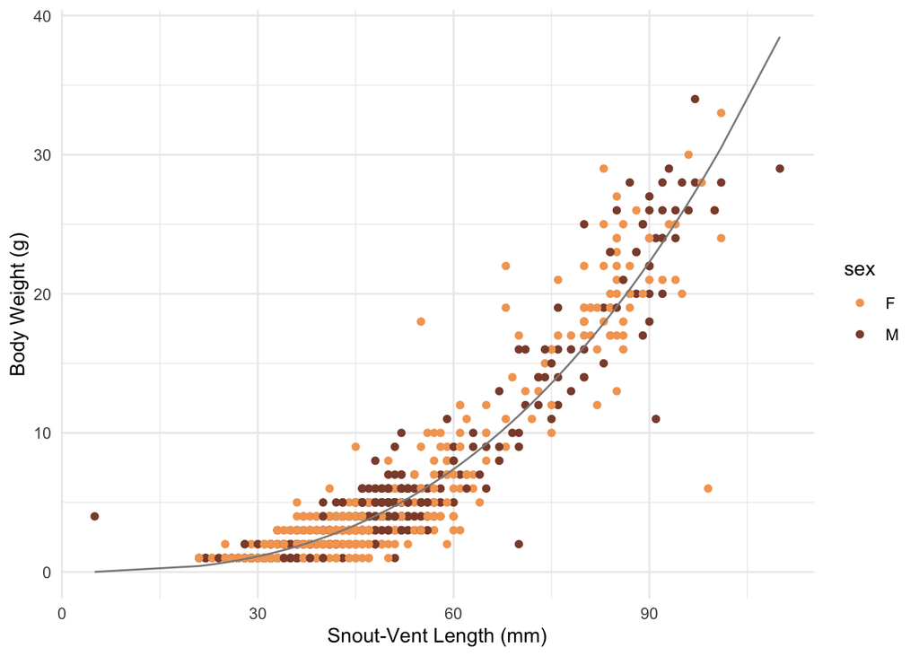

```r
predict_lizards <-lizards %>%
  mutate(predict=predict(nls_lizards,newdata=.))

# Visualization on predictions -
ggplot(data= predict_lizards) +
  geom_point(aes(x= SV_length,y= weight, color = sex))+
  labs(x = "Snout-Vent Length (mm)",
      y = "Body Weight (g)")+
  geom_line(aes(x=SV_length,y=predict), color='snow4') +
  scale_color_manual(values= c("sandybrown", "salmon4"))+
  theme_minimal()+
  theme(plot.title = element_text(hjust = 0.5))
```

```r
## Add figure caption
```

### NLS for male Western Whiptail lizard, *Cnemidophorus tigrisatus*

```r
# Filtering out for male western whiptails
male_whip_lizards <- lizards %>%
  filter(spp == "CNTI", sex == "M")
```

#### Model selection

```r
# create a function in R using given model
f1 <- function(a,b,length){
 out= a*(length^b)
return(out)
}
```

#### Initial Guess through standard OLS

```r
# run OLS regression on log transformed data
guess_model_whip <- lm(log(male_whip_lizards$weight) ~ log(male_whip_lizards$SV_length), data = male_whip_lizards)

# get coefficients
coefficients(guess_model_whip)
```

```
##                      (Intercept) log(male_whip_lizards$SV_length)
##                        -9.023963                         2.698108
```

```r
# Coefficients
# (Intercept) log(lizards$SV_length)
#  -9.023963             2.698108

# mathematically transform the intercept coefficient to get the guess for parameter a
b_whip <- guess_model_whip$coefficients[2]
a_whip <- exp((guess_model_whip$coefficients[1]))
```

#### Run NLS

```r
nls_lizards_whip <- nls(weight~f1(a,b,SV_length),
                  data=male_whip_lizards,
                  start=list(a = a_whip, b=b_whip),
                  trace=TRUE)
```

```
## 849.1572    (2.38e-01): par = (0.0001204877 2.698108)
## 845.6613    (2.27e-01): par = (0.0001330208 2.674996)
## 843.4176    (2.19e-01): par = (0.000145976 2.653427)
## 841.8629    (2.14e-01): par = (0.0001592699 2.633319)
## 840.6339    (2.09e-01): par = (0.0001728179 2.614592)
## 839.5079    (2.05e-01): par = (0.0001865362 2.597165)
## 838.3596    (2.00e-01): par = (0.0002003434 2.580958)
## 837.1280    (1.96e-01): par = (0.0002141623 2.565892)
## 835.7939    (1.91e-01): par = (0.0002279206 2.551894)
## 834.3628    (1.85e-01): par = (0.0002415522 2.538892)
## 832.8544    (1.80e-01): par = (0.0002549974 2.526816)
## 831.2942    (1.74e-01): par = (0.0002682034 2.515604)
## 830.9229    (1.72e-01): par = (0.0002940453 2.494784)
## 829.4806    (1.66e-01): par = (0.0003185494 2.476905)
## 827.3386    (1.57e-01): par = (0.0003414678 2.461569)
## 826.9172    (1.55e-01): par = (0.0003838388 2.435273)
## 822.7939    (1.37e-01): par = (0.0004187718 2.416406)
## 818.0645    (1.14e-01): par = (0.0004743039 2.389404)
## 809.0350    (4.10e-02): par = (0.0005336902 2.365838)
## 807.6757    (1.94e-04): par = (0.0005309859 2.368548)
## 807.6756    (1.74e-05): par = (0.0005316264 2.368276)
## 807.6756    (1.56e-06): par = (0.0005315662 2.368301)
```

```r
# summary(nls_lizards_whip), preliminary summary table
# Create table
broom::tidy(nls_lizards_whip) %>%
  kable(caption = "Table 2: NLS Results for Male Western Whiptail Lizard Subset") %>%
      kable_styling(full_width = FALSE,
                bootstrap_options = "hover",
                position = "center")
```

Table 2: NLS Results for Male Western Whiptail Lizard Subset

| term | estimate | std.error | statistic | p.value |
| --- | --- | --- | --- | --- |
| a | 0.0005316 | 0.0004288 | 1.239686 | 0.2192313 |
| b | 2.3683013 | 0.1800348 | 13.154689 | 0.0000000 |

#### Make a prediction based on the model

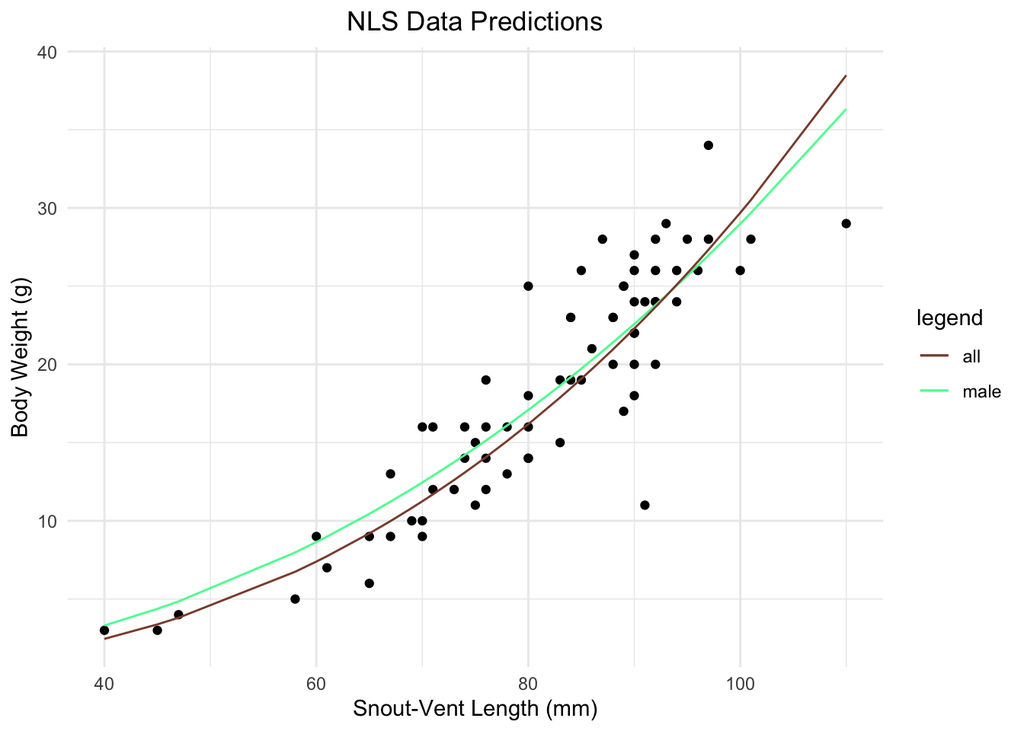

```r
# prediction for whiptail model
predict_lizards_whip <- male_whip_lizards %>%
  mutate(predict=predict(nls_lizards_whip,newdata=.)) %>%
# prediction for lizard model on whiptail dataset
  mutate(predict_with_orignls = predict(nls_lizards, newdata=.))

# plot both predictions on graph together
ggplot(data = predict_lizards_whip) +
  geom_point(aes(x= SV_length,
                 y= weight))+
  labs(x = "Snout-Vent Length (mm)",
      y = "Body Weight (g)",
      title = "NLS Data Predictions") +
    geom_line(aes(x = SV_length,
                  y = predict,
                  color="male")) +
  geom_line(aes(x = SV_length,
                y = predict_with_orignls,
                color="all")) +
  scale_colour_manual(name= "legend",
                      values=c("male"="seagreen1","all"= "salmon4")) +
  theme_minimal() +
  theme(plot.title = element_text(hjust = 0.5))
```

```r
# calculate RMSE for both models
#function for RMSE
all_lizards_rmse <- rmse(predict_lizards_whip$weight, predict_lizards_whip$predict_with_orignls)
whip_rmse <- rmse(predict_lizards_whip$weight, predict_lizards_whip$predict)
```

**Figure 2. NLS Models - Western Whiptail Lizard vs. All Species** Snout-vent length (mm) and body weight (g) are demonstrated for male western whiptail lizards versus all species and sexes in green and brown lines, respectively. The RMSE for the male species specific NLS model is 3.349 and the RMSE for the all species model is 3.462. Due to a lower root-mean square error, the male whiptail lizard model should be used to predict the selected data.

**Data Citation:** Lightfoot, D. and W.G. Whitford. 2020. Lizard pitfall trap data from 11 NPP study locations at the Jornada Basin LTER site, 1989-2006 ver 37. Environmental Data Initiative. https://doi.org/10.6073/pasta/4a6e258fb49c31e222ecbbcfd128967f.